# Risk Factor Analysis

## Outcome Variable

**Outcome Variable:** y_rate_haz

## Predictor Variables

**Intervention Variable:** fhtcm

**Adjustment Set:**

- arm
- W_mage
- W_fage
- meducyrs
- feducyrs
- W_mhtcm
- W_mwtkg
- W_mbmi
- single
- delta_W_fage
- delta_meducyrs
- delta_feducyrs
- delta_W_mhtcm
- delta_W_mwtkg
- delta_W_mbmi
- delta_single

## Stratifying Variables

The analysis was stratified on these variable(s):

- agecat
- studyid
- country

## Data Summary

| agecat | studyid | country | fhtcm | n_cell | n |
| --- | --- | --- | --- | --- | --- |
| 0-3 months | ki1000304b-SAS-CompFeed | INDIA | >=167 cm | 326 | 716 |
| 0-3 months | ki1000304b-SAS-CompFeed | INDIA | <162 cm | 184 | 716 |
| 0-3 months | ki1000304b-SAS-CompFeed | INDIA | [162-167) cm | 206 | 716 |
| 0-3 months | ki1101329-Keneba | GAMBIA | >=167 cm | 631 | 965 |
| 0-3 months | ki1101329-Keneba | GAMBIA | <162 cm | 75 | 965 |
| 0-3 months | ki1101329-Keneba | GAMBIA | [162-167) cm | 259 | 965 |
| 0-3 months | ki1119695-PROBIT | BELARUS | >=167 cm | 10773 | 11500 |
| 0-3 months | ki1119695-PROBIT | BELARUS | <162 cm | 151 | 11500 |
| 0-3 months | ki1119695-PROBIT | BELARUS | [162-167) cm | 576 | 11500 |
| 0-3 months | ki1135781-COHORTS | GUATEMALA | >=167 cm | 25 | 180 |
| 0-3 months | ki1135781-COHORTS | GUATEMALA | <162 cm | 106 | 180 |
| 0-3 months | ki1135781-COHORTS | GUATEMALA | [162-167) cm | 49 | 180 |
| 3-6 months | ki1000304b-SAS-CompFeed | INDIA | >=167 cm | 308 | 682 |
| 3-6 months | ki1000304b-SAS-CompFeed | INDIA | <162 cm | 175 | 682 |
| 3-6 months | ki1000304b-SAS-CompFeed | INDIA | [162-167) cm | 199 | 682 |
| 3-6 months | ki1101329-Keneba | GAMBIA | >=167 cm | 673 | 1037 |
| 3-6 months | ki1101329-Keneba | GAMBIA | <162 cm | 74 | 1037 |
| 3-6 months | ki1101329-Keneba | GAMBIA | [162-167) cm | 290 | 1037 |
| 3-6 months | ki1119695-PROBIT | BELARUS | >=167 cm | 9473 | 10104 |
| 3-6 months | ki1119695-PROBIT | BELARUS | <162 cm | 129 | 10104 |
| 3-6 months | ki1119695-PROBIT | BELARUS | [162-167) cm | 502 | 10104 |
| 3-6 months | ki1135781-COHORTS | GUATEMALA | >=167 cm | 37 | 261 |
| 3-6 months | ki1135781-COHORTS | GUATEMALA | <162 cm | 148 | 261 |
| 3-6 months | ki1135781-COHORTS | GUATEMALA | [162-167) cm | 76 | 261 |
| 6-12 months | ki1000304b-SAS-CompFeed | INDIA | >=167 cm | 313 | 679 |
| 6-12 months | ki1000304b-SAS-CompFeed | INDIA | <162 cm | 164 | 679 |
| 6-12 months | ki1000304b-SAS-CompFeed | INDIA | [162-167) cm | 202 | 679 |
| 6-12 months | ki1000304b-SAS-FoodSuppl | INDIA | >=167 cm | 89 | 328 |
| 6-12 months | ki1000304b-SAS-FoodSuppl | INDIA | <162 cm | 132 | 328 |
| 6-12 months | ki1000304b-SAS-FoodSuppl | INDIA | [162-167) cm | 107 | 328 |
| 6-12 months | ki1101329-Keneba | GAMBIA | >=167 cm | 635 | 1005 |
| 6-12 months | ki1101329-Keneba | GAMBIA | <162 cm | 78 | 1005 |
| 6-12 months | ki1101329-Keneba | GAMBIA | [162-167) cm | 292 | 1005 |
| 6-12 months | ki1119695-PROBIT | BELARUS | >=167 cm | 9248 | 9870 |
| 6-12 months | ki1119695-PROBIT | BELARUS | <162 cm | 124 | 9870 |
| 6-12 months | ki1119695-PROBIT | BELARUS | [162-167) cm | 498 | 9870 |
| 6-12 months | ki1135781-COHORTS | GUATEMALA | >=167 cm | 45 | 329 |
| 6-12 months | ki1135781-COHORTS | GUATEMALA | <162 cm | 192 | 329 |
| 6-12 months | ki1135781-COHORTS | GUATEMALA | [162-167) cm | 92 | 329 |
| 12-24 months | ki1101329-Keneba | GAMBIA | >=167 cm | 583 | 931 |
| 12-24 months | ki1101329-Keneba | GAMBIA | <162 cm | 73 | 931 |
| 12-24 months | ki1101329-Keneba | GAMBIA | [162-167) cm | 275 | 931 |
| 12-24 months | ki1119695-PROBIT | BELARUS | >=167 cm | 2169 | 2320 |
| 12-24 months | ki1119695-PROBIT | BELARUS | <162 cm | 38 | 2320 |
| 12-24 months | ki1119695-PROBIT | BELARUS | [162-167) cm | 113 | 2320 |
| 12-24 months | ki1135781-COHORTS | GUATEMALA | >=167 cm | 58 | 421 |
| 12-24 months | ki1135781-COHORTS | GUATEMALA | <162 cm | 244 | 421 |
| 12-24 months | ki1135781-COHORTS | GUATEMALA | [162-167) cm | 119 | 421 |

The following strata were considered:

- agecat: 0-3 months, studyid: ki1000304b-SAS-CompFeed, country: INDIA
- agecat: 0-3 months, studyid: ki1101329-Keneba, country: GAMBIA
- agecat: 0-3 months, studyid: ki1119695-PROBIT, country: BELARUS
- agecat: 0-3 months, studyid: ki1135781-COHORTS, country: GUATEMALA
- agecat: 12-24 months, studyid: ki1101329-Keneba, country: GAMBIA
- agecat: 12-24 months, studyid: ki1119695-PROBIT, country: BELARUS
- agecat: 12-24 months, studyid: ki1135781-COHORTS, country: GUATEMALA
- agecat: 3-6 months, studyid: ki1000304b-SAS-CompFeed, country: INDIA
- agecat: 3-6 months, studyid: ki1101329-Keneba, country: GAMBIA
- agecat: 3-6 months, studyid: ki1119695-PROBIT, country: BELARUS
- agecat: 3-6 months, studyid: ki1135781-COHORTS, country: GUATEMALA
- agecat: 6-12 months, studyid: ki1000304b-SAS-CompFeed, country: INDIA
- agecat: 6-12 months, studyid: ki1000304b-SAS-FoodSuppl, country: INDIA
- agecat: 6-12 months, studyid: ki1101329-Keneba, country: GAMBIA
- agecat: 6-12 months, studyid: ki1119695-PROBIT, country: BELARUS
- agecat: 6-12 months, studyid: ki1135781-COHORTS, country: GUATEMALA

## Methods Detail

We’re interested in the causal parameters $E[Y_a]$ for all values of $a \in \mathcal{A}$. These parameters represent the mean outcome if, possibly contrary to fact, we intervened to set all units to have $A=a$. Under the randomization and positivity assumptions, these are identified by the statistical parameters $\psi_a=E_W[E_{Y|A,W}(Y|A=a,W)]$. In addition, we’re interested in the mean of $Y$, $E[Y]$ under no intervention (the observed mean). We will estimate these parameters by using SuperLearner to fit the relevant likelihood factors – $E_{Y|A,W}(Y|A=a,W)$ and $p(A=a|W)$, and then updating our likelihood fit using a joint TMLE.

For unadjusted analyses ($W=\{\}$), initial likelihoods were estimated using Lrnr_glm to estimate the simple $E(Y|A)$ and Lrnr_mean to estimate $p(A)$. For adjusted analyses, a small library containing Lrnr_glmnet, Lrnr_xgboost, and Lrnr_mean was used.

Having estimated these parameters, we will then use the delta method to estimate relative risks and attributable risks relative to a prespecified baseline level of $A$.

# Results Detail

## Results Plots

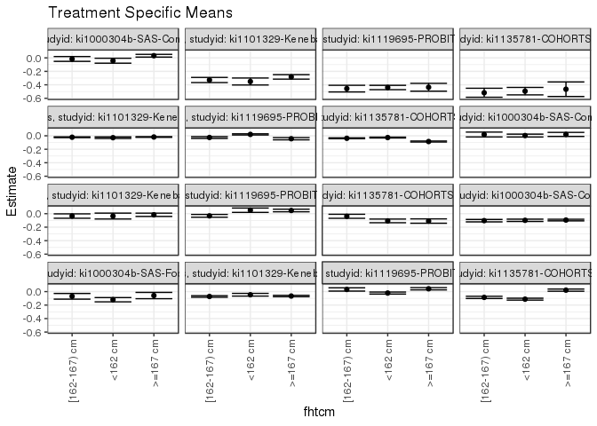

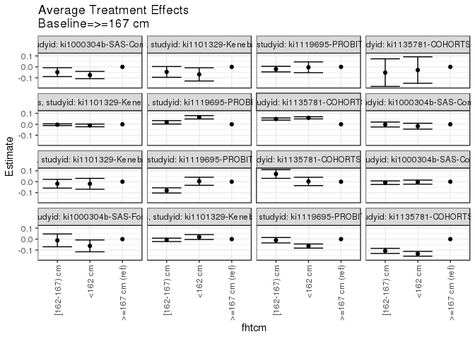

## Results Table

### Parameter: TSM

| agecat | studyid | country | intervention_level | baseline_level | estimate | ci_lower | ci_upper |
| --- | --- | --- | --- | --- | --- | --- | --- |
| 0-3 months | ki1000304b-SAS-CompFeed | INDIA | >=167 cm | NA | 0.0320206 | 0.0115913 | 0.0524499 |
| 0-3 months | ki1000304b-SAS-CompFeed | INDIA | <162 cm | NA | -0.0423949 | -0.0789170 | -0.0058729 |
| 0-3 months | ki1000304b-SAS-CompFeed | INDIA | [162-167) cm | NA | -0.0159179 | -0.0518310 | 0.0199951 |
| 0-3 months | ki1101329-Keneba | GAMBIA | >=167 cm | NA | -0.2825413 | -0.3157925 | -0.2492902 |
| 0-3 months | ki1101329-Keneba | GAMBIA | <162 cm | NA | -0.3508290 | -0.4026749 | -0.2989830 |
| 0-3 months | ki1101329-Keneba | GAMBIA | [162-167) cm | NA | -0.3282207 | -0.3664138 | -0.2900277 |
| 0-3 months | ki1119695-PROBIT | BELARUS | >=167 cm | NA | -0.4361017 | -0.4942506 | -0.3779529 |
| 0-3 months | ki1119695-PROBIT | BELARUS | <162 cm | NA | -0.4396236 | -0.4719662 | -0.4072811 |
| 0-3 months | ki1119695-PROBIT | BELARUS | [162-167) cm | NA | -0.4561622 | -0.5054573 | -0.4068672 |
| 0-3 months | ki1135781-COHORTS | GUATEMALA | >=167 cm | NA | -0.4651426 | -0.5731843 | -0.3571010 |
| 0-3 months | ki1135781-COHORTS | GUATEMALA | <162 cm | NA | -0.4939306 | -0.5491821 | -0.4386790 |
| 0-3 months | ki1135781-COHORTS | GUATEMALA | [162-167) cm | NA | -0.5174596 | -0.5840565 | -0.4508626 |
| 3-6 months | ki1000304b-SAS-CompFeed | INDIA | >=167 cm | NA | 0.0205314 | -0.0096014 | 0.0506642 |
| 3-6 months | ki1000304b-SAS-CompFeed | INDIA | <162 cm | NA | 0.0031934 | -0.0180725 | 0.0244593 |
| 3-6 months | ki1000304b-SAS-CompFeed | INDIA | [162-167) cm | NA | 0.0187429 | -0.0173077 | 0.0547936 |
| 3-6 months | ki1101329-Keneba | GAMBIA | >=167 cm | NA | -0.0163103 | -0.0405591 | 0.0079385 |
| 3-6 months | ki1101329-Keneba | GAMBIA | <162 cm | NA | -0.0352179 | -0.0789075 | 0.0084716 |
| 3-6 months | ki1101329-Keneba | GAMBIA | [162-167) cm | NA | -0.0347254 | -0.0670656 | -0.0023852 |
| 3-6 months | ki1119695-PROBIT | BELARUS | >=167 cm | NA | 0.0476543 | 0.0284090 | 0.0668997 |
| 3-6 months | ki1119695-PROBIT | BELARUS | <162 cm | NA | 0.0516049 | 0.0193675 | 0.0838423 |
| 3-6 months | ki1119695-PROBIT | BELARUS | [162-167) cm | NA | -0.0318618 | -0.0526708 | -0.0110528 |
| 3-6 months | ki1135781-COHORTS | GUATEMALA | >=167 cm | NA | -0.1093001 | -0.1415778 | -0.0770225 |
| 3-6 months | ki1135781-COHORTS | GUATEMALA | <162 cm | NA | -0.1068467 | -0.1342312 | -0.0794621 |
| 3-6 months | ki1135781-COHORTS | GUATEMALA | [162-167) cm | NA | -0.0386012 | -0.0684660 | -0.0087363 |
| 6-12 months | ki1000304b-SAS-CompFeed | INDIA | >=167 cm | NA | -0.0943584 | -0.1063010 | -0.0824158 |
| 6-12 months | ki1000304b-SAS-CompFeed | INDIA | <162 cm | NA | -0.0980938 | -0.1152455 | -0.0809421 |
| 6-12 months | ki1000304b-SAS-CompFeed | INDIA | [162-167) cm | NA | -0.1032710 | -0.1213101 | -0.0852319 |
| 6-12 months | ki1000304b-SAS-FoodSuppl | INDIA | >=167 cm | NA | -0.0583828 | -0.1051245 | -0.0116411 |
| 6-12 months | ki1000304b-SAS-FoodSuppl | INDIA | <162 cm | NA | -0.1199426 | -0.1515805 | -0.0883047 |
| 6-12 months | ki1000304b-SAS-FoodSuppl | INDIA | [162-167) cm | NA | -0.0696722 | -0.1117505 | -0.0275939 |
| 6-12 months | ki1101329-Keneba | GAMBIA | >=167 cm | NA | -0.0654823 | -0.0759677 | -0.0549970 |
| 6-12 months | ki1101329-Keneba | GAMBIA | <162 cm | NA | -0.0464116 | -0.0663229 | -0.0265002 |
| 6-12 months | ki1101329-Keneba | GAMBIA | [162-167) cm | NA | -0.0721227 | -0.0839095 | -0.0603359 |
| 6-12 months | ki1119695-PROBIT | BELARUS | >=167 cm | NA | 0.0420270 | 0.0253459 | 0.0587081 |
| 6-12 months | ki1119695-PROBIT | BELARUS | <162 cm | NA | -0.0211163 | -0.0364218 | -0.0058109 |
| 6-12 months | ki1119695-PROBIT | BELARUS | [162-167) cm | NA | 0.0320170 | 0.0075415 | 0.0564926 |
| 6-12 months | ki1135781-COHORTS | GUATEMALA | >=167 cm | NA | 0.0215309 | 0.0052067 | 0.0378550 |
| 6-12 months | ki1135781-COHORTS | GUATEMALA | <162 cm | NA | -0.1120228 | -0.1261834 | -0.0978622 |
| 6-12 months | ki1135781-COHORTS | GUATEMALA | [162-167) cm | NA | -0.0855782 | -0.1020491 | -0.0691073 |
| 12-24 months | ki1101329-Keneba | GAMBIA | >=167 cm | NA | -0.0180582 | -0.0233220 | -0.0127944 |
| 12-24 months | ki1101329-Keneba | GAMBIA | <162 cm | NA | -0.0281578 | -0.0395395 | -0.0167761 |
| 12-24 months | ki1101329-Keneba | GAMBIA | [162-167) cm | NA | -0.0214126 | -0.0273446 | -0.0154806 |
| 12-24 months | ki1119695-PROBIT | BELARUS | >=167 cm | NA | -0.0435084 | -0.0599639 | -0.0270528 |
| 12-24 months | ki1119695-PROBIT | BELARUS | <162 cm | NA | 0.0205169 | 0.0121678 | 0.0288660 |
| 12-24 months | ki1119695-PROBIT | BELARUS | [162-167) cm | NA | -0.0253021 | -0.0387002 | -0.0119040 |
| 12-24 months | ki1135781-COHORTS | GUATEMALA | >=167 cm | NA | -0.0853510 | -0.0928140 | -0.0778881 |
| 12-24 months | ki1135781-COHORTS | GUATEMALA | <162 cm | NA | -0.0263597 | -0.0326231 | -0.0200963 |
| 12-24 months | ki1135781-COHORTS | GUATEMALA | [162-167) cm | NA | -0.0372344 | -0.0438006 | -0.0306682 |

### Parameter: E(Y)

| agecat | studyid | country | intervention_level | baseline_level | estimate | ci_lower | ci_upper |
| --- | --- | --- | --- | --- | --- | --- | --- |
| 0-3 months | ki1000304b-SAS-CompFeed | INDIA | NA | NA | 0.0059269 | -0.0151835 | 0.0270374 |
| 0-3 months | ki1101329-Keneba | GAMBIA | NA | NA | -0.2957715 | -0.3237824 | -0.2677606 |
| 0-3 months | ki1119695-PROBIT | BELARUS | NA | NA | -0.4388567 | -0.4976461 | -0.3800673 |
| 0-3 months | ki1135781-COHORTS | GUATEMALA | NA | NA | -0.5011808 | -0.5450937 | -0.4572680 |
| 3-6 months | ki1000304b-SAS-CompFeed | INDIA | NA | NA | -0.0172047 | -0.0462110 | 0.0118016 |
| 3-6 months | ki1101329-Keneba | GAMBIA | NA | NA | -0.0243287 | -0.0453184 | -0.0033389 |
| 3-6 months | ki1119695-PROBIT | BELARUS | NA | NA | 0.0468501 | 0.0275580 | 0.0661423 |
| 3-6 months | ki1135781-COHORTS | GUATEMALA | NA | NA | -0.0725836 | -0.0990295 | -0.0461377 |
| 6-12 months | ki1000304b-SAS-CompFeed | INDIA | NA | NA | -0.0889976 | -0.1017879 | -0.0762074 |
| 6-12 months | ki1000304b-SAS-FoodSuppl | INDIA | NA | NA | -0.1157275 | -0.1449160 | -0.0865389 |
| 6-12 months | ki1101329-Keneba | GAMBIA | NA | NA | -0.0647984 | -0.0735026 | -0.0560942 |
| 6-12 months | ki1119695-PROBIT | BELARUS | NA | NA | 0.0416942 | 0.0249522 | 0.0584361 |
| 6-12 months | ki1135781-COHORTS | GUATEMALA | NA | NA | -0.1145084 | -0.1265939 | -0.1024228 |
| 12-24 months | ki1101329-Keneba | GAMBIA | NA | NA | -0.0200813 | -0.0244392 | -0.0157235 |
| 12-24 months | ki1119695-PROBIT | BELARUS | NA | NA | -0.0429109 | -0.0593629 | -0.0264588 |
| 12-24 months | ki1135781-COHORTS | GUATEMALA | NA | NA | -0.0256771 | -0.0311186 | -0.0202357 |

### Parameter: ATE

| agecat | studyid | country | intervention_level | baseline_level | estimate | ci_lower | ci_upper |
| --- | --- | --- | --- | --- | --- | --- | --- |
| 0-3 months | ki1000304b-SAS-CompFeed | INDIA | >=167 cm | >=167 cm | 0.0000000 | 0.0000000 | 0.0000000 |
| 0-3 months | ki1000304b-SAS-CompFeed | INDIA | <162 cm | >=167 cm | -0.0744155 | -0.1075940 | -0.0412371 |
| 0-3 months | ki1000304b-SAS-CompFeed | INDIA | [162-167) cm | >=167 cm | -0.0479385 | -0.0882827 | -0.0075944 |
| 0-3 months | ki1101329-Keneba | GAMBIA | >=167 cm | >=167 cm | 0.0000000 | 0.0000000 | 0.0000000 |
| 0-3 months | ki1101329-Keneba | GAMBIA | <162 cm | >=167 cm | -0.0682877 | -0.1286795 | -0.0078958 |
| 0-3 months | ki1101329-Keneba | GAMBIA | [162-167) cm | >=167 cm | -0.0456794 | -0.0949285 | 0.0035698 |
| 0-3 months | ki1119695-PROBIT | BELARUS | >=167 cm | >=167 cm | 0.0000000 | 0.0000000 | 0.0000000 |
| 0-3 months | ki1119695-PROBIT | BELARUS | <162 cm | >=167 cm | -0.0035219 | -0.0527235 | 0.0456797 |
| 0-3 months | ki1119695-PROBIT | BELARUS | [162-167) cm | >=167 cm | -0.0200605 | -0.0455756 | 0.0054547 |
| 0-3 months | ki1135781-COHORTS | GUATEMALA | >=167 cm | >=167 cm | 0.0000000 | 0.0000000 | 0.0000000 |
| 0-3 months | ki1135781-COHORTS | GUATEMALA | <162 cm | >=167 cm | -0.0287879 | -0.1494067 | 0.0918309 |
| 0-3 months | ki1135781-COHORTS | GUATEMALA | [162-167) cm | >=167 cm | -0.0523169 | -0.1780117 | 0.0733779 |
| 3-6 months | ki1000304b-SAS-CompFeed | INDIA | >=167 cm | >=167 cm | 0.0000000 | 0.0000000 | 0.0000000 |
| 3-6 months | ki1000304b-SAS-CompFeed | INDIA | <162 cm | >=167 cm | -0.0173380 | -0.0441091 | 0.0094331 |
| 3-6 months | ki1000304b-SAS-CompFeed | INDIA | [162-167) cm | >=167 cm | -0.0017885 | -0.0242574 | 0.0206804 |
| 3-6 months | ki1101329-Keneba | GAMBIA | >=167 cm | >=167 cm | 0.0000000 | 0.0000000 | 0.0000000 |
| 3-6 months | ki1101329-Keneba | GAMBIA | <162 cm | >=167 cm | -0.0189076 | -0.0684287 | 0.0306134 |
| 3-6 months | ki1101329-Keneba | GAMBIA | [162-167) cm | >=167 cm | -0.0184151 | -0.0582972 | 0.0214671 |
| 3-6 months | ki1119695-PROBIT | BELARUS | >=167 cm | >=167 cm | 0.0000000 | 0.0000000 | 0.0000000 |
| 3-6 months | ki1119695-PROBIT | BELARUS | <162 cm | >=167 cm | 0.0039506 | -0.0329460 | 0.0408472 |
| 3-6 months | ki1119695-PROBIT | BELARUS | [162-167) cm | >=167 cm | -0.0795161 | -0.1030866 | -0.0559457 |
| 3-6 months | ki1135781-COHORTS | GUATEMALA | >=167 cm | >=167 cm | 0.0000000 | 0.0000000 | 0.0000000 |
| 3-6 months | ki1135781-COHORTS | GUATEMALA | <162 cm | >=167 cm | 0.0024535 | -0.0353742 | 0.0402812 |
| 3-6 months | ki1135781-COHORTS | GUATEMALA | [162-167) cm | >=167 cm | 0.0706990 | 0.0308302 | 0.1105677 |
| 6-12 months | ki1000304b-SAS-CompFeed | INDIA | >=167 cm | >=167 cm | 0.0000000 | 0.0000000 | 0.0000000 |
| 6-12 months | ki1000304b-SAS-CompFeed | INDIA | <162 cm | >=167 cm | -0.0037353 | -0.0222556 | 0.0147849 |
| 6-12 months | ki1000304b-SAS-CompFeed | INDIA | [162-167) cm | >=167 cm | -0.0089126 | -0.0254689 | 0.0076437 |
| 6-12 months | ki1000304b-SAS-FoodSuppl | INDIA | >=167 cm | >=167 cm | 0.0000000 | 0.0000000 | 0.0000000 |
| 6-12 months | ki1000304b-SAS-FoodSuppl | INDIA | <162 cm | >=167 cm | -0.0615598 | -0.1153803 | -0.0077392 |
| 6-12 months | ki1000304b-SAS-FoodSuppl | INDIA | [162-167) cm | >=167 cm | -0.0112894 | -0.0696074 | 0.0470286 |
| 6-12 months | ki1101329-Keneba | GAMBIA | >=167 cm | >=167 cm | 0.0000000 | 0.0000000 | 0.0000000 |
| 6-12 months | ki1101329-Keneba | GAMBIA | <162 cm | >=167 cm | 0.0190708 | -0.0032434 | 0.0413849 |
| 6-12 months | ki1101329-Keneba | GAMBIA | [162-167) cm | >=167 cm | -0.0066404 | -0.0220762 | 0.0087955 |
| 6-12 months | ki1119695-PROBIT | BELARUS | >=167 cm | >=167 cm | 0.0000000 | 0.0000000 | 0.0000000 |
| 6-12 months | ki1119695-PROBIT | BELARUS | <162 cm | >=167 cm | -0.0631433 | -0.0821820 | -0.0441047 |
| 6-12 months | ki1119695-PROBIT | BELARUS | [162-167) cm | >=167 cm | -0.0100100 | -0.0346070 | 0.0145870 |
| 6-12 months | ki1135781-COHORTS | GUATEMALA | >=167 cm | >=167 cm | 0.0000000 | 0.0000000 | 0.0000000 |
| 6-12 months | ki1135781-COHORTS | GUATEMALA | <162 cm | >=167 cm | -0.1335537 | -0.1552514 | -0.1118559 |
| 6-12 months | ki1135781-COHORTS | GUATEMALA | [162-167) cm | >=167 cm | -0.1071091 | -0.1303098 | -0.0839083 |
| 12-24 months | ki1101329-Keneba | GAMBIA | >=167 cm | >=167 cm | 0.0000000 | 0.0000000 | 0.0000000 |
| 12-24 months | ki1101329-Keneba | GAMBIA | <162 cm | >=167 cm | -0.0100996 | -0.0225682 | 0.0023691 |
| 12-24 months | ki1101329-Keneba | GAMBIA | [162-167) cm | >=167 cm | -0.0033544 | -0.0111691 | 0.0044604 |
| 12-24 months | ki1119695-PROBIT | BELARUS | >=167 cm | >=167 cm | 0.0000000 | 0.0000000 | 0.0000000 |
| 12-24 months | ki1119695-PROBIT | BELARUS | <162 cm | >=167 cm | 0.0640253 | 0.0485776 | 0.0794729 |
| 12-24 months | ki1119695-PROBIT | BELARUS | [162-167) cm | >=167 cm | 0.0182062 | 0.0026267 | 0.0337858 |
| 12-24 months | ki1135781-COHORTS | GUATEMALA | >=167 cm | >=167 cm | 0.0000000 | 0.0000000 | 0.0000000 |
| 12-24 months | ki1135781-COHORTS | GUATEMALA | <162 cm | >=167 cm | 0.0589914 | 0.0491937 | 0.0687891 |
| 12-24 months | ki1135781-COHORTS | GUATEMALA | [162-167) cm | >=167 cm | 0.0481167 | 0.0382676 | 0.0579657 |